# Stat 202: Lecture 18 (covers pp. 192-198)

Nathan VanHoudnos  
11/3/2014

### Agenda

1. Homework comments
2. Checkpoint comments
3. Lecture 18 (covers pp. 192-198)

### Homework Comments

### Confidence intervals

- **FALSE**: The 95% confidence interval I just calculated has a 95% chance of containing the true value. **FALSE**
- **TRUE**: Over many repeated experiments, 95% of the confidence intervals you construct will contain the true value. **TRUE**

[figure not shown]

### Inference

- Point estimation
- Interval estimation
  - Confidence Intervals – If we repeat the experiment over and over, 95% of intervals will contain the true value.
  - Credible Intervals – If we do the experiment once, the probability that the true value is contained within the interval is 95%.
- **Hypothesis Testing**
  - can be useful
  - and, yet, as it stands, is a literal pox upon science.

### Mechanics before politics

A case of suspected cheating on an exam is brought in front of the disciplinary committee at a certain university.

There are two opposing claims in this case:

The student's claim: I did not cheat on the exam.

The instructor's claim: The student did cheat on the exam.

### Mechanics before politics

“innocent until proven guilty”

- the instructor must give **sufficient evidence** that the **claim of innocence** is unlikely

The instructor says:

- The exam had two versions with different values of \( \mu \), \( \sigma \), and \( n \) between the two versions.
- This student used the values of \( \mu \), \( \sigma \), and \( n \) from the **other exam version** to get the answer.
- The student did this for **three** out of the four exam questions.

### Mechanics before politics

“innocent until proven guilty”

- the instructor must give **sufficient evidence** that the **claim of innocence** is unlikely

The instructor says the student used the other set of numbers for three out of the four exam questions.

Is this sufficient evidence to **reject the claim of innocence** ?

Yes. We can reject the claim of innocence.

### Hypothesis testing

**Step 1**: State the claims. \[ \begin{aligned} H_0 & \text{ : null hypothesis} & H_A & \text{ : alt. hypothesis} \end{aligned} \]

- \( H_0 \) the student is innocent
- \( H_A \) the student is guilty

**Step 2**: Present evidence against \( H_0 \)

- The instructor presents evidence that the student cheated.

**Step 3**: Decide if \( H_0 \) should be rejected or retained.

- \( H_0 \) is rejected. The student cheated.

### Why do it this way?

**[Karl Popper](http://en.wikipedia.org/wiki/Karl_Popper)**

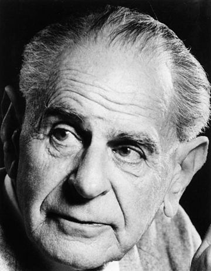

1902 - 1994

Claim:

> All swans are white.
- Finding millions upon millions of white swans does not prove this claim.
- If, there exists a single black swan, then the claim is false.

Popper argued that, if a theory is **falsifiable**, then it is scientific.

### Why do it this way?

**[Louis de Broglie](http://en.wikipedia.org/wiki/Louis_de_Broglie)**

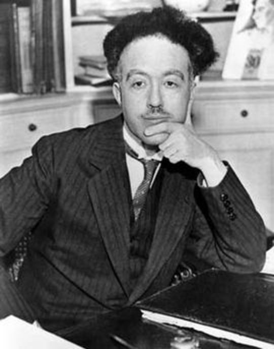

1892 - 1987

Before quantum mechanics, scientists thought that electrons, protons, neutrons and the like were essentially little billiard balls.

- \( H_0 \) (prevailing model) The electron is a particle.
- de Broglie's (1924) Ph.D. thesis showed that electrons act like waves.
- \( H_0 \) is rejected, and quantum mechanics gains strength

### Neyman-Pearson Theory

**[Karl Pearson](http://en.wikipedia.org/wiki/Karl_Pearson)**

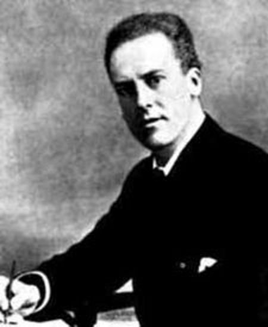

1857-1936

**[Jerzy Neyman](http://en.wikipedia.org/wiki/Jerzy_Neyman)**

1894-1981

- Student of Pearson's

### Neyman-Pearson Theory

**[Jerzy Neyman](http://en.wikipedia.org/wiki/Jerzy_Neyman)**

1894-1981

Formalized hypothesis testing in the vein of Popper.

- \( H_0 \) is **not proven** (one million white swans does not prove that all swans are white)
- \( H_0 \) is either
  - **rejected** (we found a black swan!), or
  - **retained** (we found another white swan).

### Neyman-Pearson Theory

**[Jerzy Neyman](http://en.wikipedia.org/wiki/Jerzy_Neyman)**

1894-1981

Formalized hypothesis testing in the vein of Popper.

Very influential:

- How the FDA tests drugs
- How grant proposals are judged by the federal government

### Statistical example #1

A recent study estimated that 20% of all college students in the United States smoke. Northwestern University claims that the proportion of smokers is lower here. The head of NU Health Services chooses a random sample of 400 NU students, and finds that 70 of them are smokers.

What are the null and alternate hypotheses?  
(Hint: \( H_0 \) is assumed. The burden of proof is on \( H_A \).)

\[ \begin{aligned} & a) & H_0 & : p = .2 & & b) & & H_0 : p \le .20 \\ & & H_A & : p \le .2 & & & & H_A : p = .20 \end{aligned} \]

Choice \( a) \) is correct.

### Statistical example #2

A [report on the College Board website](http://www.collegeboard.com/prod_downloads/about/news_info/cbsenior/yr2003/pdf/2003CBSVM.pdf), showed that in 2003, males scored generally higher than females on the SAT exam. An educational researcher wanted to check whether this was also the case in her school district.

Let \( \mu_M \) and \( \mu_F \) be the population means for males and females respectively. What are the null and alternate hypotheses?

\[ \begin{aligned} & a) & H_0 & : \mu_M = \mu_F & & b) & & H_0 : \mu_M = \mu_F \\ & & H_A & : \mu_M \ne \mu_F & & & & H_A : \mu_M \ge \mu_F \end{aligned} \]

Choice \( b) \).

### Statistical example #3

A medicine is supposed to contain an average of 245 parts per million (ppm) of a certain chemical. If the concentration is higher, the drug will cause side effects, and if the concentration is lower, the drug may not work. The manufacturer wants to check whether the mean concentration in a large shipment is the required 245 ppm or not with a hypothesis test.

What are the null and alternate hypotheses?

\[ \begin{aligned} & a) & H_0 & : \mu = 245 & & b) & & H_0 : \mu \ne 245 \\ & & H_A & : \mu \ne 245 & & & & H_A : \mu = 245 \end{aligned} \]

Choice \( a) \).

### $$\text{When to reject } H_0 ?$$

- Consider example #3:
  - \( H_0 : \mu = 245 \) (the mean is correct)
  - \( H_A : \mu \ne 245 \) (the mean is not correct)
- Recall that a 95% confidence interval (CI) for \( \mu \)
  - will **not contain \( \mu \) with 95% probability**, but
  - over many experiments, 95% of such CIs will contain \( \mu \).
  - (He's dead Jim.)

### $$\text{When to reject } H_0 ?$$

- Consider example #3:
  - \( H_0 : \mu = 245 \) (the mean is correct)
  - \( H_A : \mu \ne 245 \) (the mean is not correct)
- If \( H_0 \) is true, then over many experiments
  - 95% of **95% CIs** will contain \( 245 \), and
  - 5% of **95% CIs** will not contain \( 245 \).

### $$\text{When to reject } H_0 ?$$

**Means of 25 experiments cluster around 245**

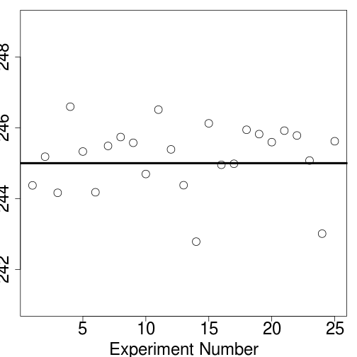

**About 95% of the 25 confidence intervals contain 245**

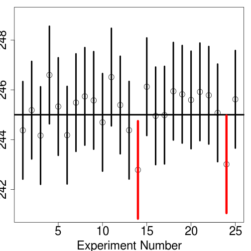

### $$\text{When to reject } H_0 ?$$

- If \( H_0 \) is true, then over many experiments
  - 95% of **95% CIs** will contain \( 245 \), and
  - 5% of **95% CIs** will not contain \( 245 \).
- Make a rule:
  - **retain \( H_0 \)** when the 95% CI contains 245,
  - **reject \( H_0 \)** when it does not contain 245.
- If \( H_0 \) is true, then
  - 95% of **experiments** will **correctly retain \( H_0 \)**
  - 5% of **experiments** will **incorrectly reject \( H_0 \)**.

### What if 5% is not enough?

- If \( H_0 \) is true, then over many experiments
  - 95% of **95% CIs** will contain \( 245 \), and
  - 5% of **95% CIs** will not contain \( 245 \).
- If \( H_0 \) is true, then over many experiments
  - 99.7% of **99.7% CIs** will contain \( 245 \), and
  - 0.3% of **99.7% CIs** will not contain \( 245 \).
- Make a new rule:
  - **retain \( H_0 \)** when the 99.7% CI contains 245,
  - **reject \( H_0 \)** when it does not contain 245.

### A 99.7% rule instead of 95%

**About 95% of the 25 confidence intervals contain 245**

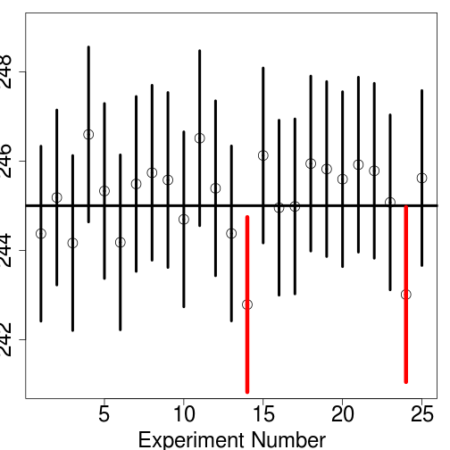

**About 99.7% of the 25 confidence intervals contain 245**

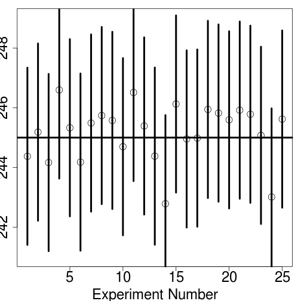

### A 99.7% rule instead of 95%

**About 95% of the 1,000 confidence intervals contain 245**

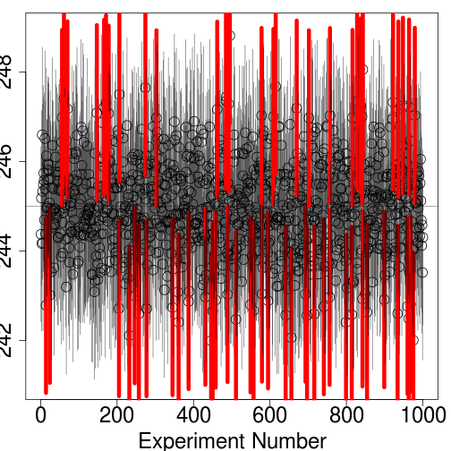

**About 99.7% of the 1,000 confidence intervals contain 245**

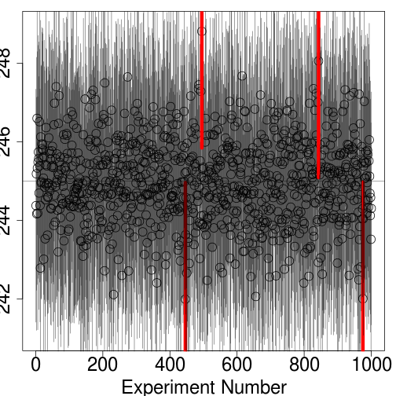

### $$\text{Controlling error when } H_0 \text{ is true.}$$

If \( H_0 \) is true, we can control **which percentage of experiments** incorrectly reject \( H_0 \):

- a 95% CI will **incorrectly reject** 5% of the **experiments** \[ \bar{x} \pm 2 \cdot \sigma/\sqrt{n} \]
- a 99.7% CI will **incorrectly reject** 0.3% of the **experiments** \[ \bar{x} \pm 3 \cdot \sigma/\sqrt{n} \]
- a \( (1 - \alpha)\cdot 100\% \) CI will **incorrectly reject** \( \alpha \)% of the **experiments** \[ \bar{x} \pm z_{\alpha/2} \cdot \sigma/\sqrt{n} \]

### Pretend to be the FDA

The Federal Drug Administration (FDA) wants to make sure that drugs are effective. For a new drug, the FDA requires that the maker of the drug perform a double-blind randomized controlled trial to determine effectiveness.

Let \( d \) be the (true) effect of the treatment. If the drug is not effective, \( d = 0 \). If the drug is effective, \( d \ge 0 \). (Assume that drugs at this stage of FDA approval are never harmful.)

What should \( H_0 \) and \( H_A \) be?

\( H_0 : d = 0 \) (the drug has no effect )  
\( H_A : d \ge 0 \) (the drug has a positive effect)

### Pretend to be the FDA

- If \( H_0 \) is true **for every drug**, then the FDA will
  - **correctly retain \( H_0 \)** for 95% of drugs
  - **incorrectly reject \( H_0 \)** for 5% of drugs
- If \( H_0 \) is true **for every drug**, then the FDA will
  - decide that 95% of (useless!) drugs as not effective
  - decide that 5% of (useless!) drugs are effective.

> The FDA can control the number of incorrect rejections it makes (**Type I error**). If 5% is too high, they can pick a different Type I error rate.

### The mistakes we can make

We must either **Retain \( H_0 \)** or **Reject \( H_0 \)**.

```r
             Retain H0   |  Reject H0
==========|==============|===============
          |              |
==========|==============|===============
          |              |
==========|==============|===============
```

### The mistakes we can make

We must either **Retain \( H_0 \)** or **Reject \( H_0 \)**.

If \( H_0 \) is true, then

```r
             Retain H0   |  Reject H0
==========|==============|===============
H0 true   |   Good!      |  MISTAKE!
==========|==============|===============
          |              |
==========|==============|===============
```

### The mistakes we can make

We must either **Retain \( H_0 \)** or **Reject \( H_0 \)**.

If \( H_0 \) is false, then

```r
             Retain H0   |  Reject H0
==========|==============|===============
H0 true   |   Good!      |  MISTAKE!
==========|==============|===============
H0 false  |   MISTAKE!   |  Good!
==========|==============|===============
```

### The mistakes we can make

We must either **Retain \( H_0 \)** or **Reject \( H_0 \)**.

The two mistakes have special names:

```r
             Retain H0    |  Reject H0
==========|===============|===============
H0 true   |  Good!        |  Type I error
==========|===============|===============
H0 false  | Type II error |  Good!
==========|===============|===============
```

> Note: Everything **thus far** has focused on \( H_0 \) being true. We will get to Type II error in detail later.

### Everyone makes mistakes, so why can't you?

[figure not shown]

Big Bird  
Sesame Workshop

Hypothesis testing is best understood as

- a formal way to make a **decision** such that
- you **control** the number of times you **falsely reject** \( H_0 \) when \( H_0 \) is, in fact, true.
- If everyone makes mistakes, let's control how often we make a **Type I error over the course of our careers**.